# BREWERY ANALYSIS

Casey Martinez & Asha Saxena

October 18, 2017

## INTRODUCTION:

Youtube: https://www.youtube.com/watch?v=2j5r0kXmBCk

The global craft beer market size was valued at USD 85.02 billion and is expected to witness significant growth over the forecast period owing to the increasing penetration of the product.

As the craft beer segment of the beer market continues to grow, Beverage Industry takes an in-depth look at the segment and its future.

#### We are tasked to analyze the beer and breweries data for its Alcoholic Content (ABV) and Bitterness Level(IBU) and respond to the BIG question:

#### **What is the rising consumer preference expected to be the key aspects of the market growth?**

### SCOPE & PHASES

Scope of this project is as follows: 1) Analyzing the data set provided for breweries and beer in United States 2) Cleaning the Data 3) Computing the data set 4) Evaluating the statistical results 5) Conclusion

## PHASE 1: ANALYZING THE DATA

```r
library(ggplot2)
library(data.table)
library(dplyr)
library(ggthemes)
source('Analysis/makefile.R')
```

### Q1. How many breweries are present in each state?

We found that the data set contains 50 states in additon to Washington DC, which makes it total of 51 states enteries.

```r
#question 1
q1 <- brew %>% group_by(brew$State) %>% summarize(TotalBreweries = n())
```

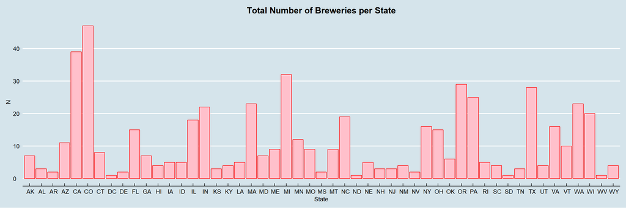

```r
q1 <- as.data.frame(q1)

q1_plot <- ggplot(data = q1, aes(x = as.factor(q1$`brew$State`),y = TotalBreweries)) +
  geom_col(color = 'red',fill = 'pink') +
  labs(y = 'N',x = "State") +
  ggtitle('Total Number of Breweries per State') +
  theme_economist() +
  theme(plot.title = element_text(hjust = 0.5))

print(q1_plot)
```

### Q2. Merge beer data with the breweries data. Print the first Six observations and the last six observations to check the merged file.

We then merged the beer and breweries data set and print the first six and the last six observations to confirm the merged file.

## PHASE 2: DATA CLEANZING

```r
#Question 2
head(merged_data, 6)
```

```
##   Brew_ID             Name.x        City State        Name.y Beer_ID   ABV
## 1       1 NorthGate Brewing  Minneapolis    MN       Pumpion    2689 0.060
## 2       1 NorthGate Brewing  Minneapolis    MN    Stronghold    2688 0.060
## 3       1 NorthGate Brewing  Minneapolis    MN   Parapet ESB    2687 0.056
## 4       1 NorthGate Brewing  Minneapolis    MN  Get Together    2692 0.045
## 5       1 NorthGate Brewing  Minneapolis    MN Maggie's Leap    2691 0.049
## 6       1 NorthGate Brewing  Minneapolis    MN    Wall's End    2690 0.048
##   IBU                               Style Ounces
## 1  38                         Pumpkin Ale     16
## 2  25                     American Porter     16
## 3  47 Extra Special / Strong Bitter (ESB)     16
## 4  50                        American IPA     16
## 5  26                  Milk / Sweet Stout     16
## 6  19                   English Brown Ale     16
```

```r
tail(merged_data, 6)
```

```
##      Brew_ID                        Name.x          City State
## 2405     556         Ukiah Brewing Company         Ukiah    CA
## 2406     557       Butternuts Beer and Ale Garrattsville    NY
## 2407     557       Butternuts Beer and Ale Garrattsville    NY
## 2408     557       Butternuts Beer and Ale Garrattsville    NY
## 2409     557       Butternuts Beer and Ale Garrattsville    NY
## 2410     558 Sleeping Lady Brewing Company     Anchorage    AK
##                         Name.y Beer_ID   ABV IBU                   Style
## 2405             Pilsner Ukiah      98 0.055  NA         German Pilsener
## 2406         Porkslap Pale Ale      49 0.043  NA American Pale Ale (APA)
## 2407           Snapperhead IPA      51 0.068  NA            American IPA
## 2408         Moo Thunder Stout      50 0.049  NA      Milk / Sweet Stout
## 2409  Heinnieweisse Weissebier      52 0.049  NA              Hefeweizen
## 2410 Urban Wilderness Pale Ale      30 0.049  NA        English Pale Ale
##      Ounces
## 2405     12
## 2406     12
## 2407     12
## 2408     12
## 2409     12
## 2410     12
```

### Q3. Report the number of NA’s in each column.

First step in cleaning the data is to check how many NA values we have. For ABV we find 62 and for IBU 1005 NA values.All other columns have no NA values.

```r
q3a <- sum(is.na(merged_data$ABV))
q3b <- sum(is.na(merged_data$IBU))
print(paste('The number of NA values for column ABV is:',q3a))
```

```
## [1] "The number of NA values for column ABV is: 62"
```

```r
print(paste('The number of NA values for column IBU is:',q3b))
```

```
## [1] "The number of NA values for column IBU is: 1005"
```

```r
print('All other columns have no NA values')
```

```
## [1] "All other columns have no NA values"
```

## PHASE 3: COMPUTATION

### Q4. Compute the median alcohol content and international bitterness unit for each state. Plot a bar chart to compare.

Please see attached the bar chart to compare.

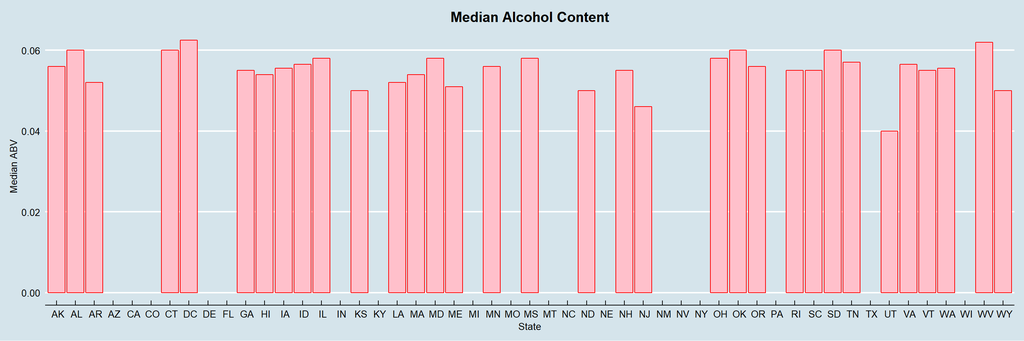

```r
#question4
q4 <- merged_data %>% group_by(merged_data$State) %>% summarize(median_ABV = median(ABV), median_IBU = median(IBU))
q4 <- as.data.frame(q4)
setnames(q4, "merged_data$State", "State")

#bar chart for median_ABV
q4a <- ggplot(data = q4, aes(x = State,y = median_ABV)) +
  geom_col(color = 'red',fill = 'pink') +
  labs(y = 'Median ABV',title = 'Median Alcohol Content') +
  theme_economist() +
  theme(plot.title = element_text(hjust = 0.5))

#bar chart for median_IBU
q4b <- ggplot(data = q4, aes(x = State,y = median_IBU)) +
  geom_col(color = 'blue',fill = 'yellow') +
  labs(y = 'Median IBU',title = 'Median International Bitterness Content') +
  theme_economist() +
  theme(plot.title = element_text(hjust = 0.5))

print(q4a)
```

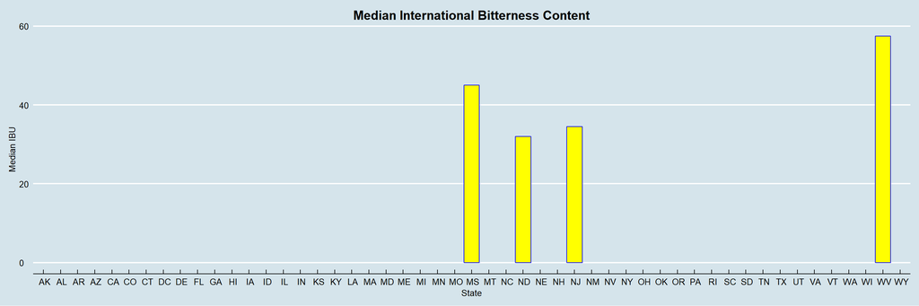

```r
print(q4b)
```

### Q5. Which state has the maximum alcoholic (ABV) beer? Which state has the most bitter (IBU) beer?

We then looked at the data to check which state has the maximum alcoholic (ABV) beer and which state has the most bitter (IBU) beer.

```r
q5a <- merged_data$State[which.max(merged_data$ABV)]
print(paste("The state with the most alcholic beer is:",as.character(q5a)))
```

```
## [1] "The state with the most alcholic beer is:  CO"
```

```r
q5b <- merged_data$State[which.max(merged_data$ABV)]
print(paste("The state with the most BITTER beer is:",as.character(q5b)))
```

[output not shown]

## PHASE 4: EVALUATING STATISTICAL RESULTS

### Q6. Summary statistics for the ABV variable.

Our goal was now to see the summary statistic for ABV variable. We found Min, Max to be 0.001 to 0.128, which show a nice range for ABV by the 51 state entries. Mean, median measures are 0.059, 0.056 and the NA’s in the ABV column are 62

```r
#question 6
q6 <- summary(merged_data$ABV)
print(q6)
```

```
##    Min. 1st Qu.  Median    Mean 3rd Qu.    Max.    NA's
## 0.00100 0.05000 0.05600 0.05977 0.06700 0.12800      62
```

## PHASE 5: CONCLUSION

### Q7. Is there an apparent relationship between the bitterness of the beer and its alcoholic content? Draw a scatter plot.

By plotting our data on a scatter plot, We see here a linear relationship between the bitterness of the beer and its alcoholic content.

For lower bitterness content and low alcoholic content, we see a concentrated population, which indicates the popular beer/beweries have low IBU/ABV content, whereas higher the bitterness and higher the alcohol content lower the concentration. We see sparadic spread of data in that region of the plot.

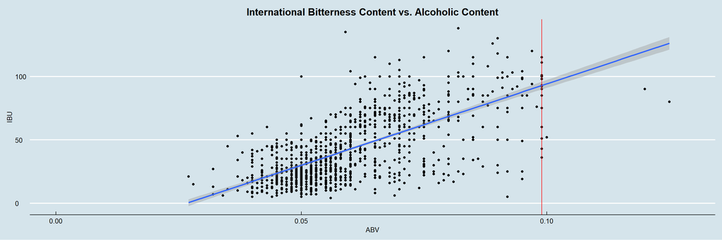

```r
#scatter plot
q7 <- ggplot(data = merged_data, aes(x = ABV,y = IBU)) +
  geom_point() +
  labs(x = 'ABV', y = 'IBU',title = 'International Bitterness Content vs. Alcoholic Content') +
  theme_economist() +
  theme(plot.title = element_text(hjust = 0.5)) +
  geom_smooth(method = 'lm') +
  geom_vline(xintercept = 0.099,color='red')

print(q7)
```

```r
#linear reegression model
q7model <- lm(IBU ~ ABV, merged_data)
summary(q7model)
```

```
##
## Call:
## lm(formula = IBU ~ ABV, data = merged_data)
##
## Residuals:
##     Min      1Q  Median      3Q     Max
## -78.849 -11.977  -0.721  13.997  93.458
##
## Coefficients:
##             Estimate Std. Error t value Pr(>|t|)
## (Intercept)  -34.099      2.326  -14.66   <2e-16 ***
## ABV         1282.037     37.860   33.86   <2e-16 ***
## ---
## Signif. codes:  0 '***' 0.001 '**' 0.01 '*' 0.05 '.' 0.1 ' ' 1
##
## Residual standard error: 19.26 on 1403 degrees of freedom
##   (1005 observations deleted due to missingness)
## Multiple R-squared:  0.4497, Adjusted R-squared:  0.4493
## F-statistic:  1147 on 1 and 1403 DF,  p-value: < 2.2e-16
```